# INTRODUCTION:

The given dataset has data of around 1599 red-wines samples with 13 variables(“X”,“fixed.acidity”,“volatile.acidity”,“citric.acid”, “residual.sugar”,“chlorides”,“free.sulfur.dioxide”,“total.sulfur.dioxide”, “density”,“pH”,“sulphates”,“alcohol”,“quality) Summary of the dataset shows that”x" is a count variables and there are some intersting features to explore in the dataset like the quality of red-wine and may be after analysis, we can comment upon the factors that control the quality of red-wine.

```
##        X          fixed.acidity   volatile.acidity  citric.acid
##  Min.   :   1.0   Min.   : 4.60   Min.   :0.1200   Min.   :0.000
##  1st Qu.: 400.5   1st Qu.: 7.10   1st Qu.:0.3900   1st Qu.:0.090
##  Median : 800.0   Median : 7.90   Median :0.5200   Median :0.260
##  Mean   : 800.0   Mean   : 8.32   Mean   :0.5278   Mean   :0.271
##  3rd Qu.:1199.5   3rd Qu.: 9.20   3rd Qu.:0.6400   3rd Qu.:0.420
##  Max.   :1599.0   Max.   :15.90   Max.   :1.5800   Max.   :1.000
##  residual.sugar     chlorides       free.sulfur.dioxide
##  Min.   : 0.900   Min.   :0.01200   Min.   : 1.00
##  1st Qu.: 1.900   1st Qu.:0.07000   1st Qu.: 7.00
##  Median : 2.200   Median :0.07900   Median :14.00
##  Mean   : 2.539   Mean   :0.08747   Mean   :15.87
##  3rd Qu.: 2.600   3rd Qu.:0.09000   3rd Qu.:21.00
##  Max.   :15.500   Max.   :0.61100   Max.   :72.00
##  total.sulfur.dioxide    density             pH          sulphates
##  Min.   :  6.00       Min.   :0.9901   Min.   :2.740   Min.   :0.3300
##  1st Qu.: 22.00       1st Qu.:0.9956   1st Qu.:3.210   1st Qu.:0.5500
##  Median : 38.00       Median :0.9968   Median :3.310   Median :0.6200
##  Mean   : 46.47       Mean   :0.9967   Mean   :3.311   Mean   :0.6581
##  3rd Qu.: 62.00       3rd Qu.:0.9978   3rd Qu.:3.400   3rd Qu.:0.7300
##  Max.   :289.00       Max.   :1.0037   Max.   :4.010   Max.   :2.0000
##     alcohol         quality
##  Min.   : 8.40   Min.   :3.000
##  1st Qu.: 9.50   1st Qu.:5.000
##  Median :10.20   Median :6.000
##  Mean   :10.42   Mean   :5.636
##  3rd Qu.:11.10   3rd Qu.:6.000
##  Max.   :14.90   Max.   :8.000
```

# Univariate Plots Section

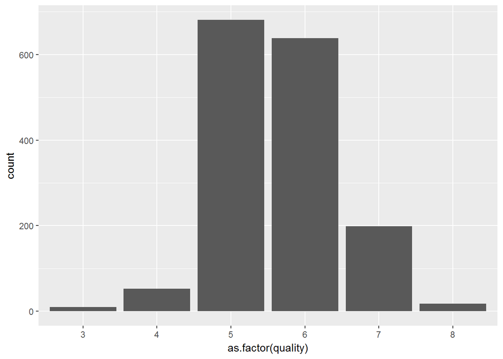

Quality is an ordered factor variable most of the red whines in the data belong to quality 5 followed by quality 6. Higher quality red wines are less frequent as suggested by plot.

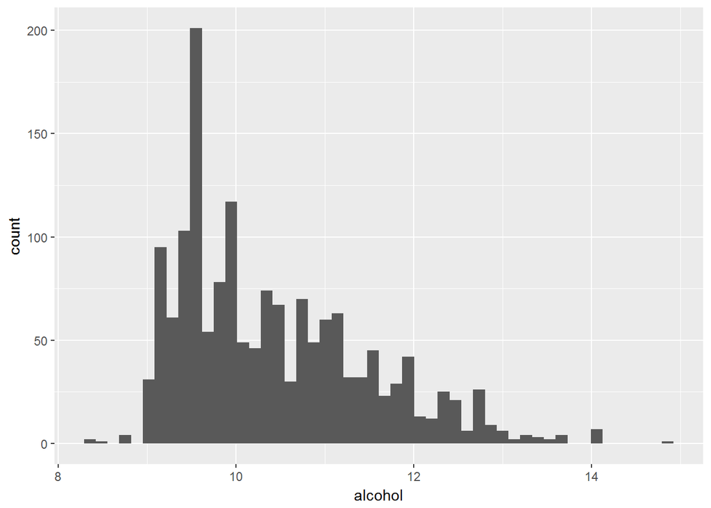

Mostly alcohol content values lies b/w 9 and 10.5 and a peak, around at an alcohol content of 9.5. Also, there are some outliers towards higher alcohol content and a few at lower side.

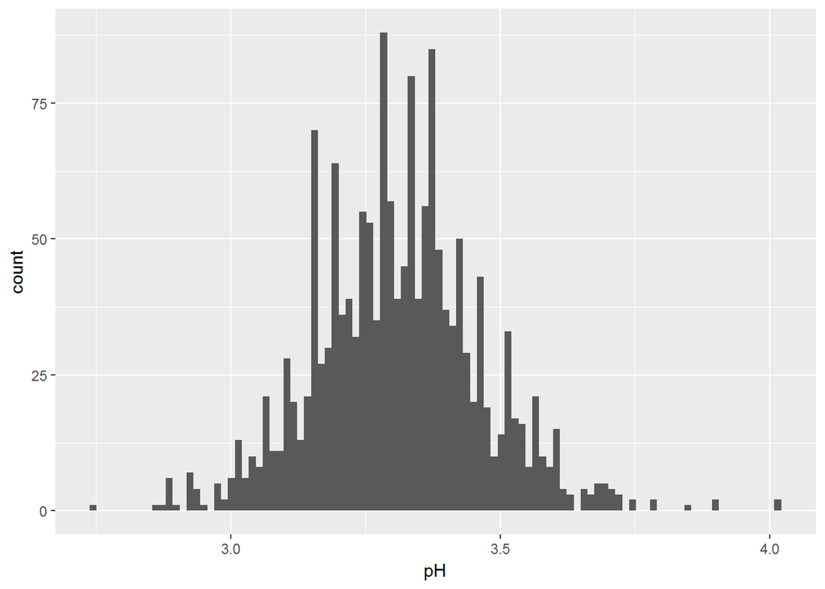

pH distribution is normal with very few outliers. Large chunk of red wines have pH values in the range (3.2-.3.3).

```
##    Min. 1st Qu.  Median    Mean 3rd Qu.    Max.
##   2.740   3.210   3.310   3.311   3.400   4.010
```

```
##         X fixed.acidity volatile.acidity citric.acid residual.sugar
## 1317 1317           5.4             0.74           0            1.2
## 1322 1322           5.0             0.74           0            1.2
##      chlorides free.sulfur.dioxide total.sulfur.dioxide density   pH
## 1317     0.041                  16                   46 0.99258 4.01
## 1322     0.041                  16                   46 0.99258 4.01
##      sulphates alcohol quality
## 1317      0.59    12.5       6
## 1322      0.59    12.5       6
```

In the plot, there are some data points at extreme right. So, I checked them with a R-code to filter the data having ph>4.

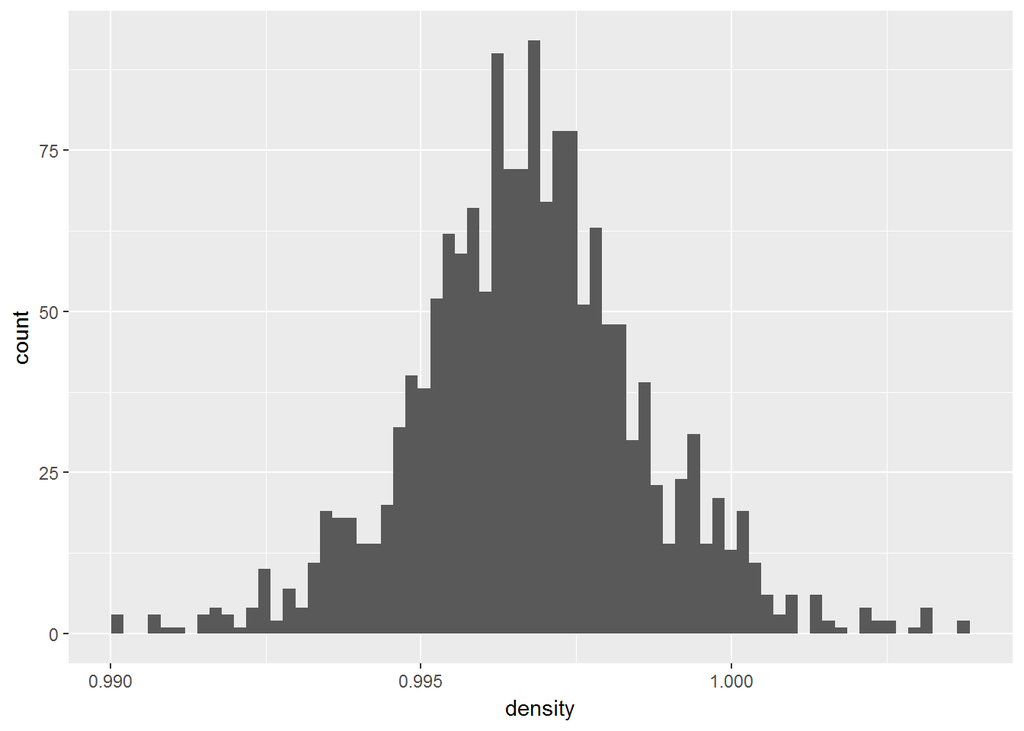

Distribution of density is normal with few outliers.

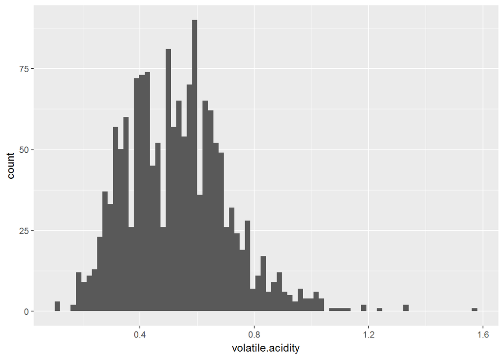

We need to use log scale in this case.

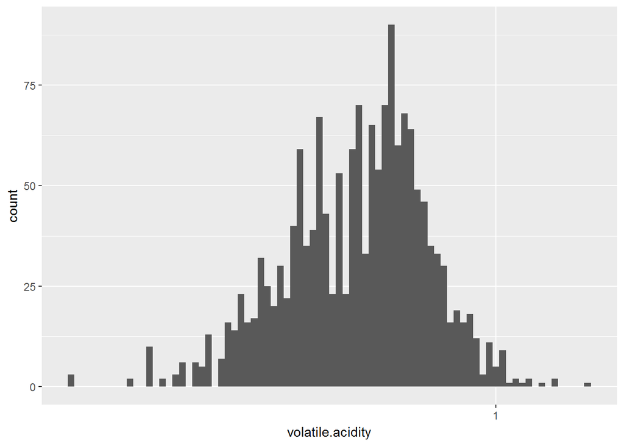

log(volatile acidity) has somewhat normal distribution. A little cleaning of data will give a better plot.

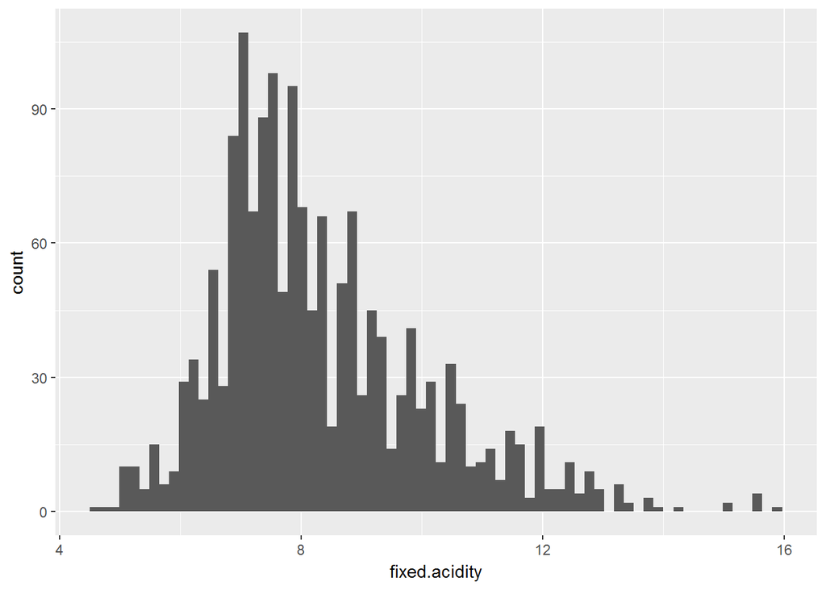

Here, we again need to use log transformation on our x-axis.

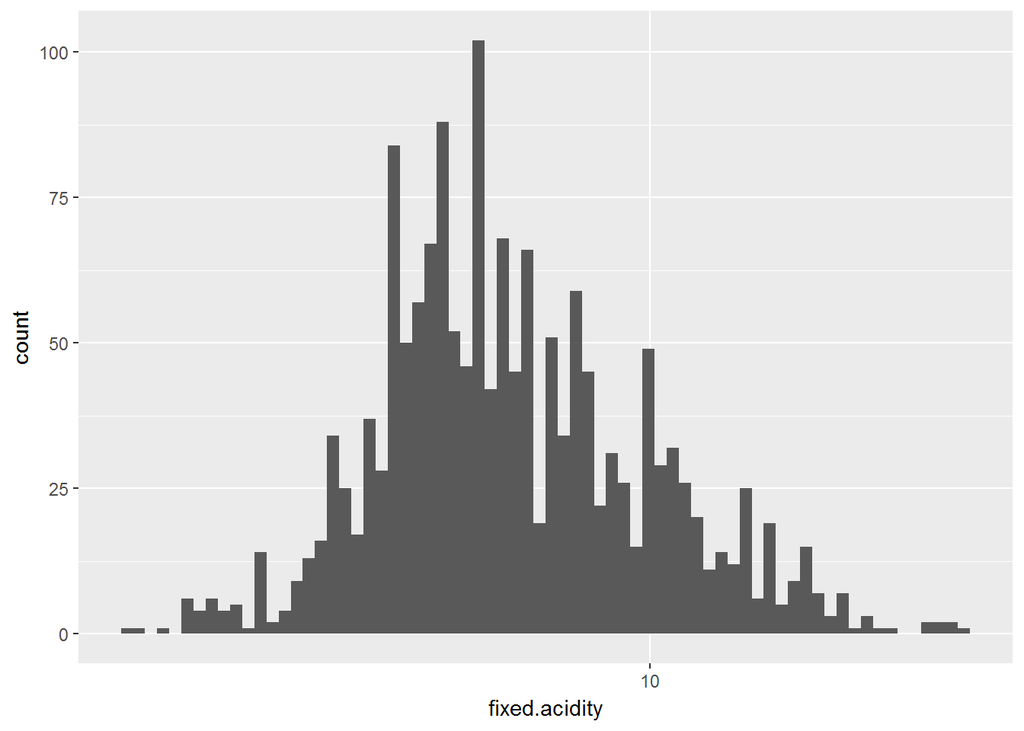

Distribution of fixed.acidity. I have used a log scale and it appears that the distribution is somewhat normal.

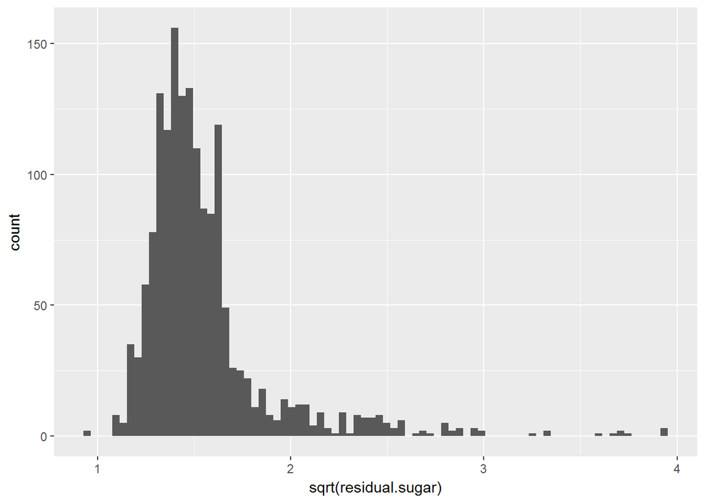

I have used a sqrt scale on x-axis. A large chunk of data is concentrated towards the left with a long tail towards higher residual sugar levels.

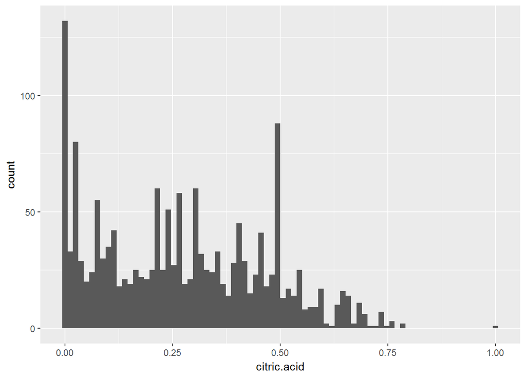

The distribution is skewed. Lets see the plot after axis transformation.

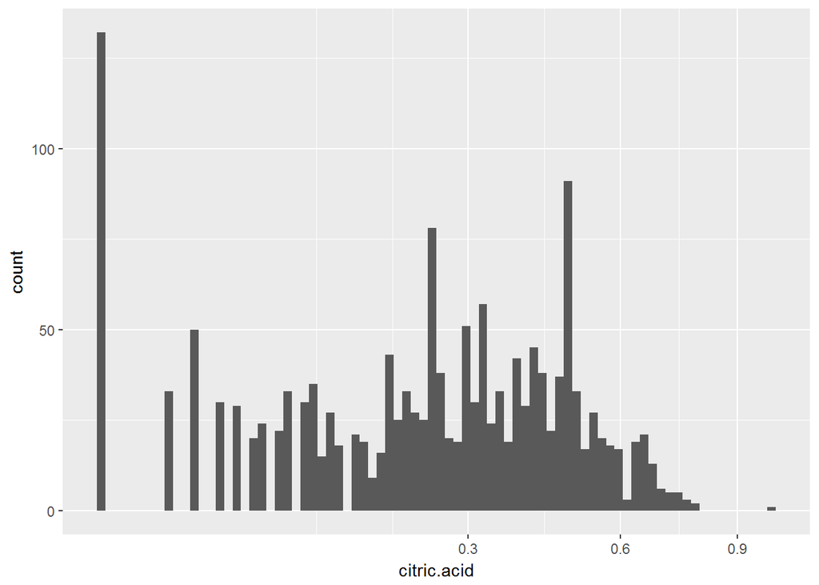

Distribution is a bit bimodal in nature. But, a lot of data values are absent in between.

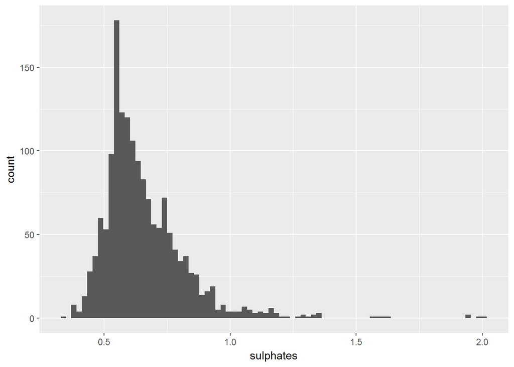

Lets use log scale on x-axis.

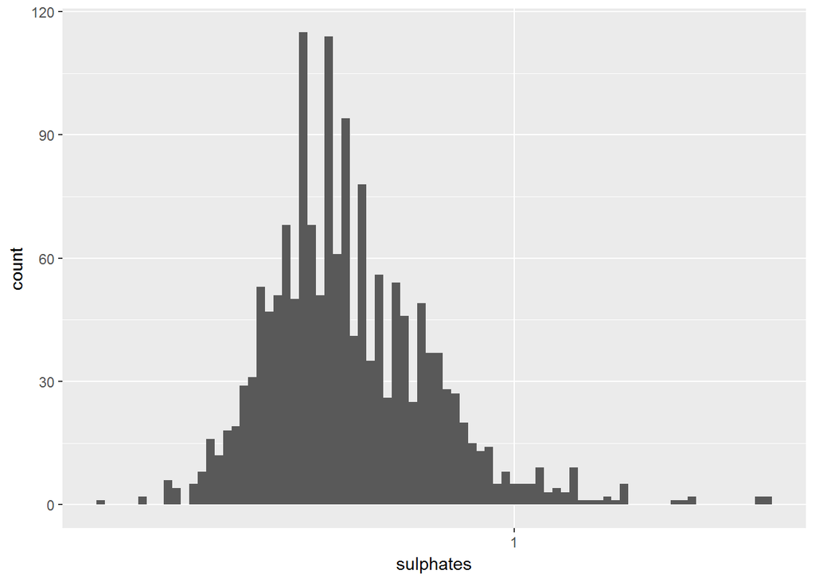

Again data is somewhat normally distributed with few ouliers that can be removed to get a better plot.

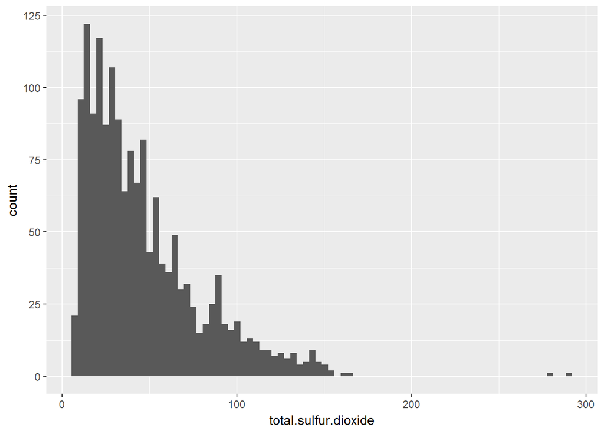

The data is highly skewed towards left. We need to use log scale.

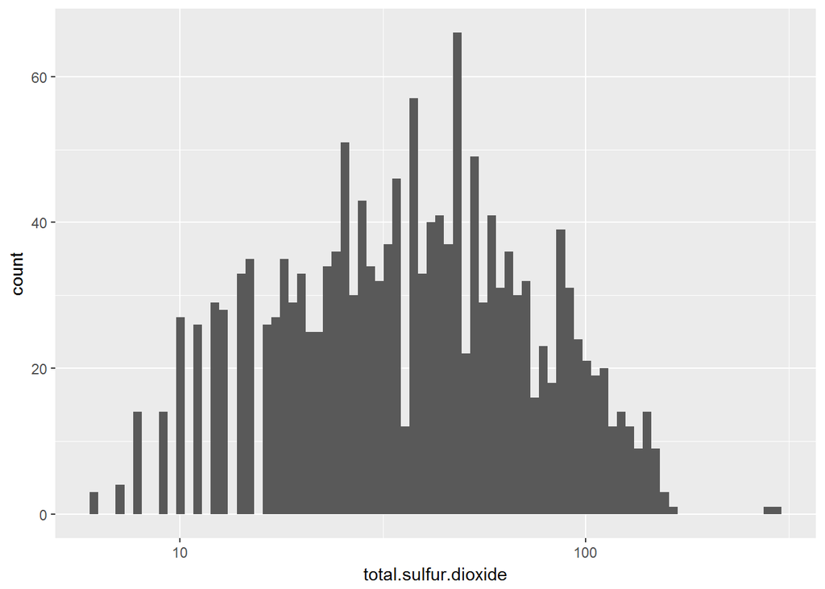

I have used log scale to even the distribution which was previously skewed towards left.

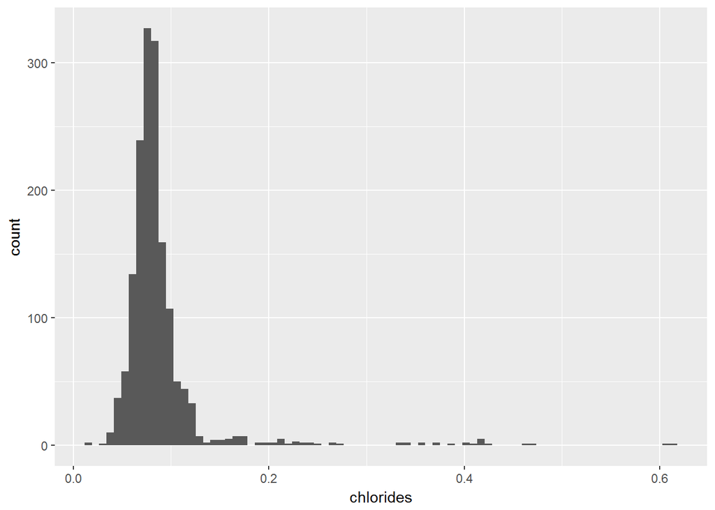

Graph without log scale

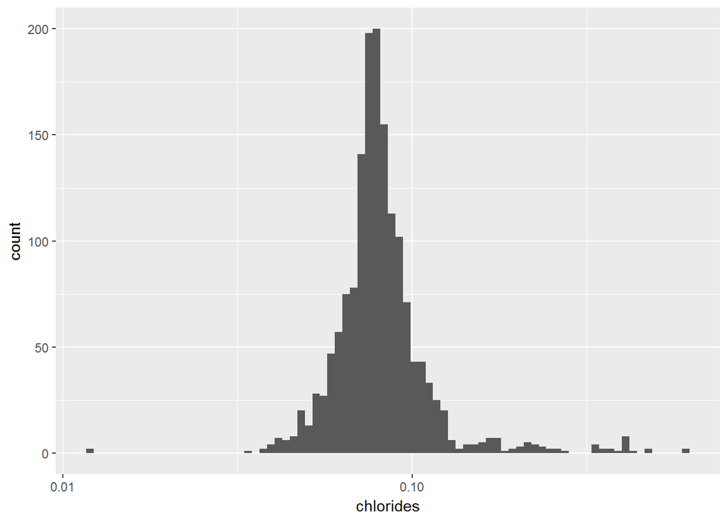

I have plotted chloride content on a log-scale. Distribution is normal with some outliers scattered around higher chloride content.

# Univariate Analysis

### What is the structure of your dataset?

The dataset(1599X13) contains information of 1599 red-wines with 13 variables (“X”,“fixed.acidity”,“volatile.acidity”,“citric.acid”,“residual.sugar”, “chlorides”,“free.sulfur.dioxide”,“total.sulfur.dioxide”,“density”,“pH”, “sulphates”,“alcohol”,“quality).”x" is a count variable. “Quality is an ordered factor variable with lowest quality being 3 and heighest being 8.

### What is/are the main feature(s) of interest in your dataset?

I would really like to work out the relationahip between quality and alcohol content of red wines. Does higher quality red wines have higher alcohol content or not. Also the variation of pH with alcohol content.

### What other features in the dataset do you think will help support your

### investigation into your feature(s) of interest?

What holds the control over pH of red wines i.e. free.sulhur.dioxide, volatile.acidity, sulphates or alcoho. Also, variation of parameters in quality 5 and 6(most counts). What features have strong co-relations. And, variation of density with quality.

### Did you create any new variables from existing variables in the dataset?

No, I didn’t create any new variables from existing variables in the dataset. But, I converted quality into 3 groups i.e. 3-5, 5-7,7-9. And, grouped parameters by quality and then summarised parameters in the quality group (5-7).

### Of the features you investigated, were there any unusual distributions?

### Did you perform any operations on the data to tidy, adjust, or change the

### form of the data? If so, why did you do this?

I used log scale and sqrt scale in univariate plots to obtain somewhat normal distribution.

# Bivariate Plots Section

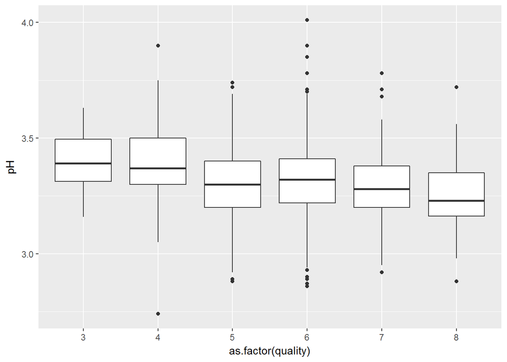

```
##
##  Pearson's product-moment correlation
##
## data:  df$pH and df$quality
## t = -2.3109, df = 1597, p-value = 0.02096
## alternative hypothesis: true correlation is not equal to 0
## 95 percent confidence interval:
##  -0.106451268 -0.008734972
## sample estimates:
##         cor
## -0.05773139
```

There is no strong correlation b/w pH and quality. Lets summarise pH variation with quality of alcohol.

```
##     item group1 vars   n     mean        sd median  trimmed      mad  min
## X11    1      3    1  10 3.398000 0.1440525   3.39 3.398750 0.148260 3.16
## X12    2      4    1  53 3.381509 0.1814408   3.37 3.383721 0.118608 2.74
## X13    3      5    1 681 3.304949 0.1506184   3.30 3.303780 0.148260 2.88
## X14    4      6    1 638 3.318072 0.1539951   3.32 3.315996 0.148260 2.86
## X15    5      7    1 199 3.290754 0.1501008   3.28 3.286087 0.133434 2.92
## X16    6      8    1  18 3.267222 0.2006403   3.23 3.263125 0.118608 2.88
##      max range         skew    kurtosis          se
## X11 3.63  0.47 -0.009144773 -1.28854080 0.045553387
## X12 3.90  1.16 -0.293059304  2.35443949 0.024922807
## X13 3.74  0.86  0.053054942 -0.01995589 0.005771711
## X14 4.01  1.15  0.301382195  1.44202134 0.006096724
## X15 3.78  0.86  0.377166503  0.58981835 0.010640361
## X16 3.72  0.84  0.354035873 -0.13122625 0.047291376
```

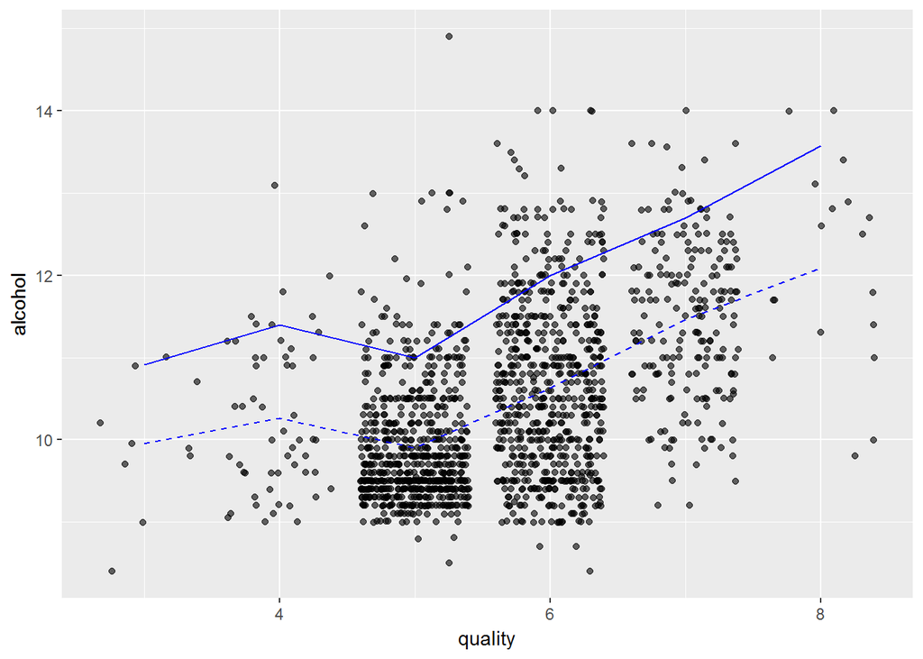

Plot between alcohol content and quality. Though for each quality of red-wine there is a fair variation of alcohol content but,the plot suggests that mean alcohol content is increasing with quality. The alocohol content dips from quality 4 to quality 5. Lets check how much they are correlated !

```
##
##  Pearson's product-moment correlation
##
## data:  df$alcohol and df$quality
## t = 21.639, df = 1597, p-value < 2.2e-16
## alternative hypothesis: true correlation is not equal to 0
## 95 percent confidence interval:
##  0.4373540 0.5132081
## sample estimates:
##       cor
## 0.4761663
```

Pearson’s r is 0.47>0.3. So, we can say that, there is moderately strong coorelation b/w alcohol content and quality of alcohol. Lets summarise alcohol content with quality of red wine.

```
##     item group1 vars   n      mean        sd median   trimmed      mad min
## X11    1      3    1  10  9.955000 0.8180091  9.925 10.018750 0.778365 8.4
## X12    2      4    1  53 10.265094 0.9347760 10.000 10.206977 1.186080 9.0
## X13    3      5    1 681  9.899706 0.7365210  9.700  9.792936 0.444780 8.5
## X14    4      6    1 638 10.629519 1.0496390 10.500 10.560449 1.186080 8.4
## X15    5      7    1 199 11.465913 0.9619330 11.500 11.466770 1.037820 9.2
## X16    6      8    1  18 12.094444 1.2240109 12.150 12.118750 1.186080 9.8
##      max range        skew   kurtosis         se
## X11 11.0   2.6 -0.40890877 -0.9932596 0.25867719
## X12 13.1   4.1  0.61327279 -0.2320630 0.12840136
## X13 14.9   6.4  1.83042317  5.2544218 0.02822355
## X14 14.0   5.6  0.54442666 -0.1579873 0.04155560
## X15 14.0   4.8  0.01033155 -0.4677010 0.06818962
## X16 14.0   4.2 -0.19693316 -0.9776767 0.28850213
```

As, suggested by the correlation plot, mean alcohol content increases with increase in quality of red wine.

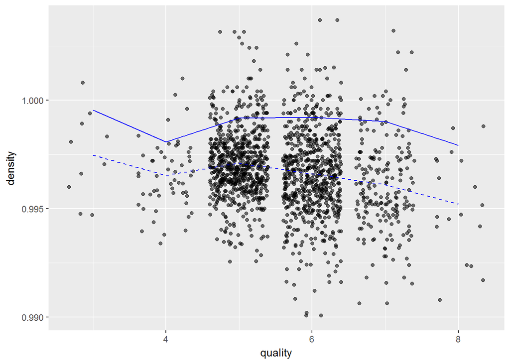

Density is decreasing initially but then it increases with increasing quality for a while only to fall again with quality From the plot, it does not appears that the two parameters are much correlated.  
Lets check it statistically!

```
##
##  Pearson's product-moment correlation
##
## data:  df$density and df$quality
## t = -7.0997, df = 1597, p-value = 1.875e-12
## alternative hypothesis: true correlation is not equal to 0
## 95 percent confidence interval:
##  -0.2220365 -0.1269870
## sample estimates:
##        cor
## -0.1749192
```

correlation is not quite relevant.A weak negative correlation isn’t much of interest. Lets summarise density distribution with quality.

```
##     item group1 vars   n      mean          sd   median   trimmed
## X11    1      3    1  10 0.9974640 0.002001845 0.997565 0.9973912
## X12    2      4    1  53 0.9965425 0.001575169 0.996500 0.9964863
## X13    3      5    1 681 0.9971036 0.001588504 0.997000 0.9970439
## X14    4      6    1 638 0.9966151 0.002000009 0.996560 0.9966091
## X15    5      7    1 199 0.9961043 0.002175739 0.995770 0.9960381
## X16    6      8    1  18 0.9952122 0.002378276 0.994940 0.9952638
##             mad     min     max   range        skew   kurtosis
## X11 0.002164596 0.99471 1.00080 0.00609  0.04759097 -1.3857107
## X12 0.001334340 0.99340 1.00100 0.00760  0.41374091  0.2593699
## X13 0.001304688 0.99256 1.00315 0.01059  0.47445877  1.3532879
## X14 0.001749468 0.99007 1.00369 0.01362  0.04705527  0.6898221
## X15 0.001971858 0.99064 1.00320 0.01256  0.33801406  0.3465896
## X16 0.003350676 0.99080 0.99880 0.00800 -0.20066076 -1.1553096
##               se
## X11 6.330389e-04
## X12 2.163661e-04
## X13 6.087162e-05
## X14 7.918111e-05
## X15 1.542341e-04
## X16 5.605649e-04
```

Mean density varies from .995 to .997.

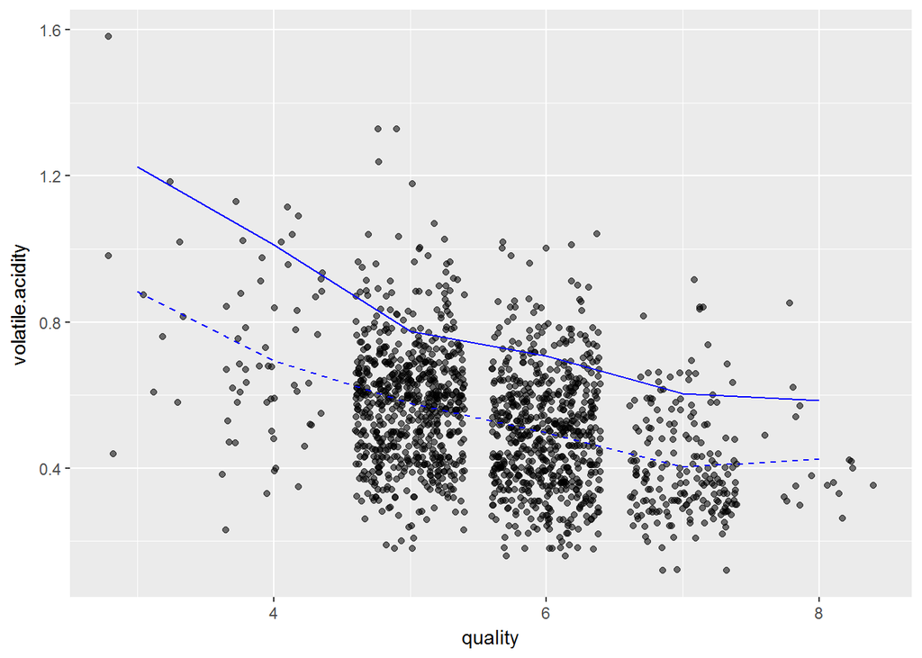

It appears from the plot that, as quality of red wine increases, volatile acidity decreases. Lets check the pearson’s r.

```
##
##  Pearson's product-moment correlation
##
## data:  df$volatile.acidity and df$quality
## t = -16.954, df = 1597, p-value < 2.2e-16
## alternative hypothesis: true correlation is not equal to 0
## 95 percent confidence interval:
##  -0.4313210 -0.3482032
## sample estimates:
##        cor
## -0.3905578
```

Yes, a negative moderately strong correlation b/w the two parameters is observed. Lets summarise this variation.

```
##     item group1 vars   n      mean        sd median   trimmed      mad
## X11    1      3    1  10 0.8845000 0.3312556  0.845 0.8531250 0.303933
## X12    2      4    1  53 0.6939623 0.2201100  0.670 0.6908140 0.252042
## X13    3      5    1 681 0.5770411 0.1648012  0.580 0.5698257 0.163086
## X14    4      6    1 638 0.4974843 0.1609623  0.490 0.4907520 0.163086
## X15    5      7    1 199 0.4039196 0.1452244  0.370 0.3903416 0.118608
## X16    6      8    1  18 0.4233333 0.1449138  0.370 0.4068750 0.074130
##      min   max range      skew    kurtosis          se
## X11 0.44 1.580 1.140 0.6270191 -0.54054899 0.104752221
## X12 0.23 1.130 0.900 0.1488264 -0.81529662 0.030234437
## X13 0.18 1.330 1.150 0.5911007  1.36339622 0.006315195
## X14 0.16 1.040 0.880 0.4327494  0.08843808 0.006372557
## X15 0.12 0.915 0.795 0.9428877  0.76022793 0.010294682
## X16 0.26 0.850 0.590 1.4455109  1.62440497 0.034156503
```

Mean value of volatile acidity varies b/w 0.40-0.89. Standard deviation is quite small too.

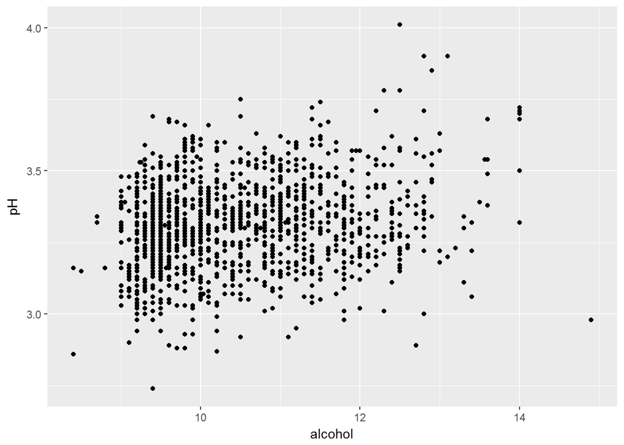

Distribution of pH vs alcohol is widely scattred. plot suggests that alcohol content doesn’t control pH of red wines. Quite interesting !

```
##
##  Pearson's product-moment correlation
##
## data:  df$pH and df$alcohol
## t = 8.397, df = 1597, p-value < 2.2e-16
## alternative hypothesis: true correlation is not equal to 0
## 95 percent confidence interval:
##  0.1582061 0.2521123
## sample estimates:
##       cor
## 0.2056325
```

As evident from the plot and from a very small value of pearson’s “r”, correlation is very weak.

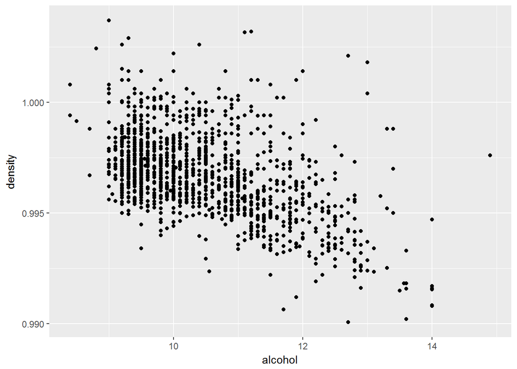

It appears that there is a negative relation b/w the two parameters. However, data is quite scattered. Lets check our assumption!

```
##
##  Pearson's product-moment correlation
##
## data:  df$density and df$alcohol
## t = -22.838, df = 1597, p-value < 2.2e-16
## alternative hypothesis: true correlation is not equal to 0
## 95 percent confidence interval:
##  -0.5322547 -0.4583061
## sample estimates:
##        cor
## -0.4961798
```

Wow! A negative correlation.

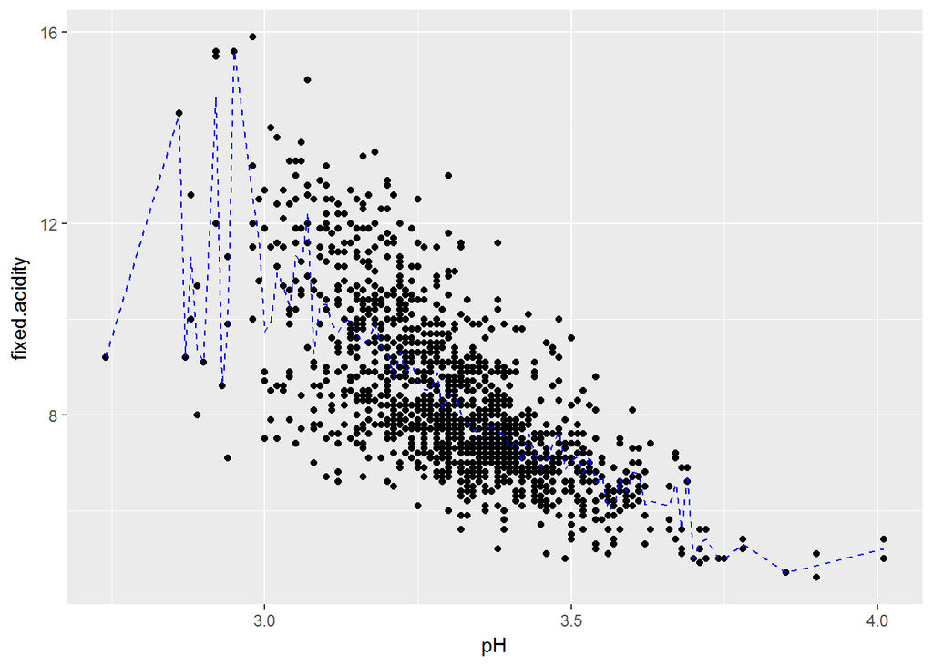

The plot suggests strongly negative correlation b/w pH and fixed acidity. Lets confirm it with pearson’s r !

```
##
##  Pearson's product-moment correlation
##
## data:  df$fixed.acidity and df$pH
## t = -37.366, df = 1597, p-value < 2.2e-16
## alternative hypothesis: true correlation is not equal to 0
## 95 percent confidence interval:
##  -0.7082857 -0.6559174
## sample estimates:
##        cor
## -0.6829782
```

Strong ngative co-relation b/w the two parameters.

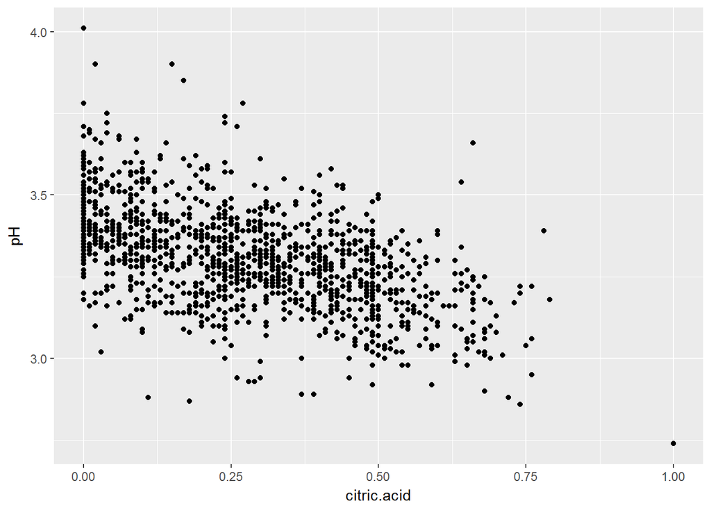

Lets check the correlation.

```
##
##  Pearson's product-moment correlation
##
## data:  df$pH and df$citric.acid
## t = -25.767, df = 1597, p-value < 2.2e-16
## alternative hypothesis: true correlation is not equal to 0
## 95 percent confidence interval:
##  -0.5756337 -0.5063336
## sample estimates:
##        cor
## -0.5419041
```

A moderately strong but negative correlation.

# Bivariate Analysis

### Talk about some of the relationships you observed in this part of the

### investigation. How did the feature(s) of interest vary with other features

### in the dataset?

I was interested in studying the relationship b/w alcohol content and quality of red wines. From the plot as well as from pearson’s r, the two parameters have quite strong correlation b/w them. Mean alcohol content increases with the quality of red wines. Quality isn’t strongly related to pH or density but related with volatile acidity. Alcohol content varied widely with pH but negatively related with density.

### Did you observe any interesting relationships between the other features

### (not the main feature(s) of interest)?

Also, before analysis I thought that alcohol content and pH would be correlated but surprisingly fixed.acidity controls the pH. The relationship between fixed.acidity and pH is quite strong too.

### What was the strongest relationship you found?

Fixed.acidity and pH

# Multivariate Plots Section

```r
breaks <- c( 3,4,6,9 )
df$quality.group <-cut(df$quality,breaks)
quality_group<-group_by(df,quality.group)
df.group <-summarise(quality_group,mean_alcohol =mean(alcohol),mean_pH= mean(pH),
                     mean_fixed.acidity= mean(fixed.acidity),
                     mean_volatile.acidity= mean(volatile.acidity),
                     mean_density= mean(density),n= n())
head(df.group)
```

```
## # A tibble: 4 × 7
##   quality.group mean_alcohol  mean_pH mean_fixed.acidity
##          <fctr>        <dbl>    <dbl>              <dbl>
## 1         (3,4]     10.26509 3.381509           7.779245
## 2         (4,6]     10.25272 3.311296           8.254284
## 3         (6,9]     11.51805 3.288802           8.847005
## 4            NA      9.95500 3.398000           8.360000
## # ... with 3 more variables: mean_volatile.acidity <dbl>,
## #   mean_density <dbl>, n <int>
```

I divided the data according to quality to get the mean values of parameters that belong to various quality ranges.In the interset group variation of parameters is as follows Mean pH = 3.311296 mean alcohol = 10.252 mean fixed acidity = 8.254 Mean volatile acidity = 0.5385 Mean Density =0.99686 NA value group isn’t useful for us.

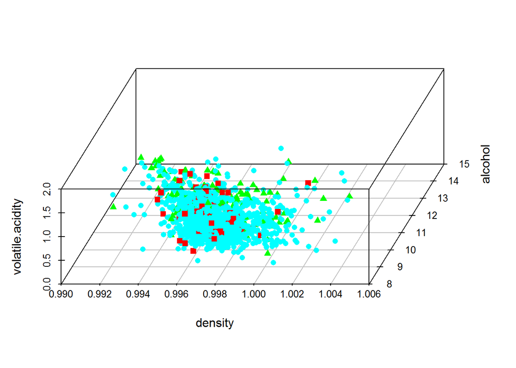

I have created a 3D plot between density, volatile acidity and alcohol content. I have used the quality group created above to colour code the data according to quality.

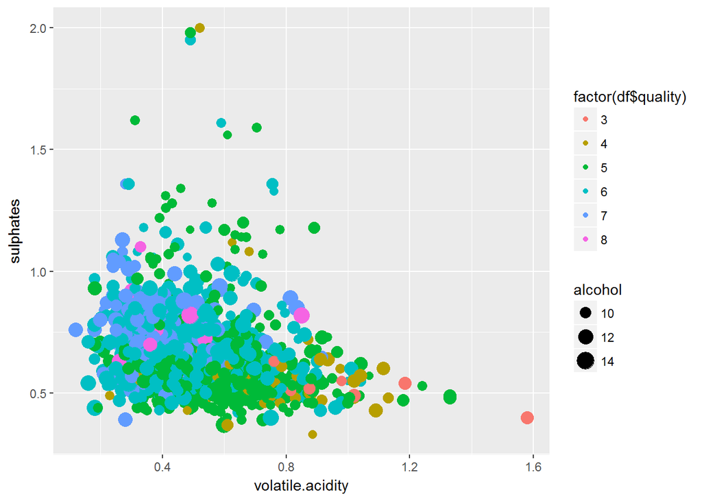

It looks like the higher quality red wines tend to be concentrated in the top left of the plot. This tends to be where the higher alcohol content (larger dots) are concentrated as well.

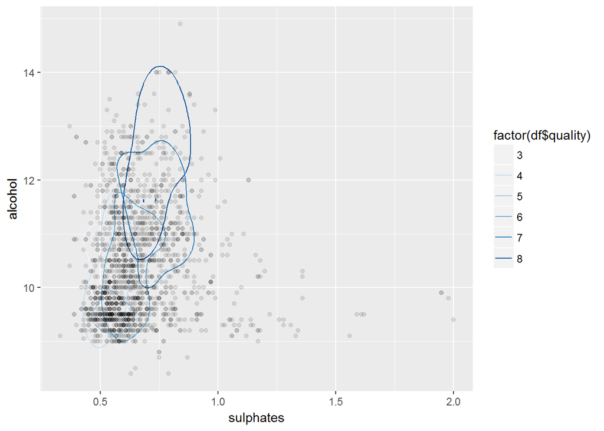

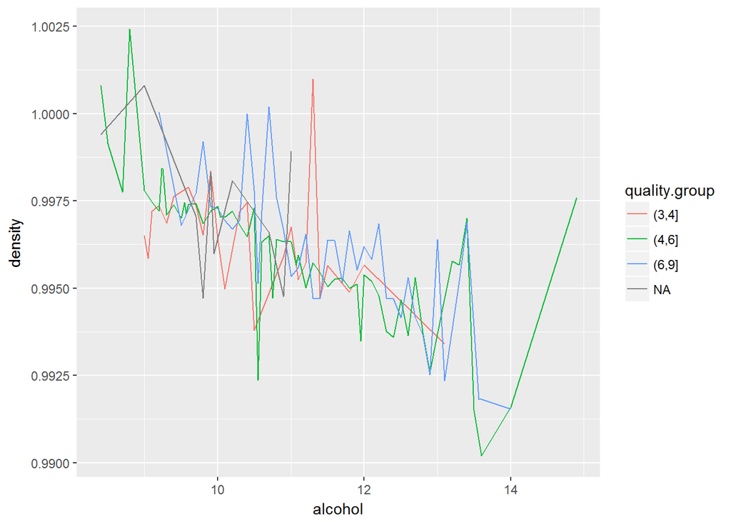

I have plotted alcohol content and density with quality to see the relation b/w the three parameters.

# Multivariate Analysis

### Talk about some of the relationships you observed in this part of

### the investigation. Were there features that strengthened each other

### in terms of looking at your feature(s) of interest?

The 3D scatter plot and lineplot shows the relation b/w 2 or more parameters as a function of quality of red wines.

### Average value of parameters with quality.

Average value of parameters in the most frequent quality range(most of the red wines belong to this group): Mean pH = 3.311 mean alcohol = 10.252 mean fixed acidity = 8.25 Mean volatile acidity = 0.53 Mean Density =0.99686

### Were there any interesting or surprising interactions between features?

Not really.

### OPTIONAL: Did you create any models with your dataset? Discuss the strengths

### and limitations of your model.

# Final Plots and Summary

### Plot One

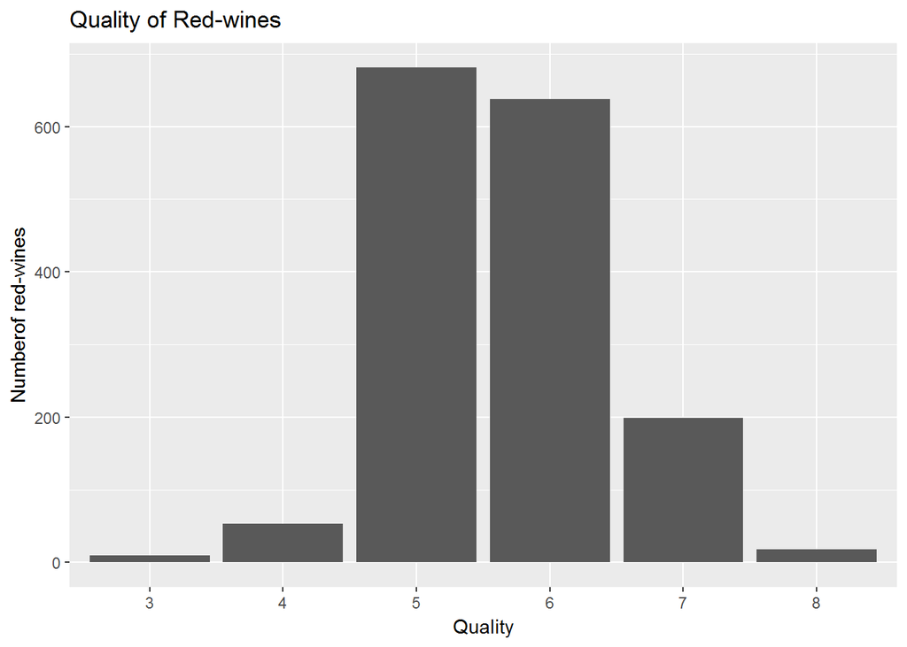

### Description One

The first plot shows the quality of red wines. Most red wines have a quality of 5 or 6. Very low quality and high quality red-wines are less frequent.

```
##    Min. 1st Qu.  Median    Mean 3rd Qu.    Max.
##   3.000   5.000   6.000   5.636   6.000   8.000
```

Mean quality is 5.636 while median is 6.

### Plot Two

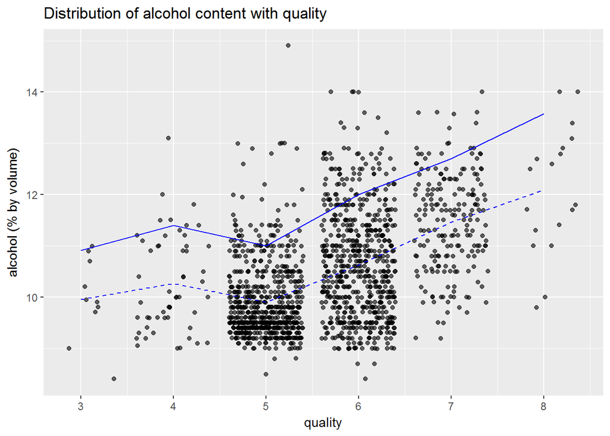

### Description Two

The plot b/w alcohol content and quality of red-wines.The plot shows a quite strong co-relation b/w the two parameters. the mean alcohol content shows the increasing nature of alcohol content with quality of red-wines.

```
##     item group1 vars   n      mean        sd median   trimmed      mad min
## X11    1      3    1  10  9.955000 0.8180091  9.925 10.018750 0.778365 8.4
## X12    2      4    1  53 10.265094 0.9347760 10.000 10.206977 1.186080 9.0
## X13    3      5    1 681  9.899706 0.7365210  9.700  9.792936 0.444780 8.5
## X14    4      6    1 638 10.629519 1.0496390 10.500 10.560449 1.186080 8.4
## X15    5      7    1 199 11.465913 0.9619330 11.500 11.466770 1.037820 9.2
## X16    6      8    1  18 12.094444 1.2240109 12.150 12.118750 1.186080 9.8
##      max range        skew   kurtosis         se
## X11 11.0   2.6 -0.40890877 -0.9932596 0.25867719
## X12 13.1   4.1  0.61327279 -0.2320630 0.12840136
## X13 14.9   6.4  1.83042317  5.2544218 0.02822355
## X14 14.0   5.6  0.54442666 -0.1579873 0.04155560
## X15 14.0   4.8  0.01033155 -0.4677010 0.06818962
## X16 14.0   4.2 -0.19693316 -0.9776767 0.28850213
```

Summary of variation of alcohol content with quality.

### Plot Three

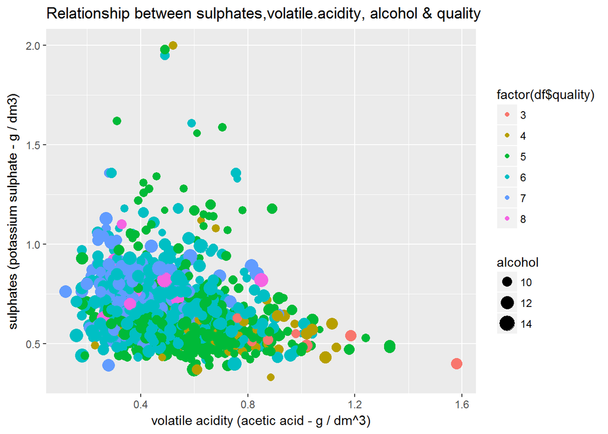

### Description Three

The plotshowsthe relationship between sulphates, volatile.acidity, alcohol and quality. The alcohol content is encoded as size and quality as color the higher quality red wines tend to be concentrated in the top left of the plot. This tends to be where the higher alcohol content (larger dots) are concentrated as well.

```
## # A tibble: 4 × 7
##   quality.group mean_alcohol  mean_pH mean_fixed.acidity
##          <fctr>        <dbl>    <dbl>              <dbl>
## 1         (3,4]     10.26509 3.381509           7.779245
## 2         (4,6]     10.25272 3.311296           8.254284
## 3         (6,9]     11.51805 3.288802           8.847005
## 4            NA      9.95500 3.398000           8.360000
## # ... with 3 more variables: mean_volatile.acidity <dbl>,
## #   mean_density <dbl>, n <int>
```

variation of parameters within quality groups.

# Reflection

The dataset contains information of about 1599 redwines with 13 variables to represent its characteristics. Mostly parameters followed somewhat normal distribution. Mostly redwines in the data belong to quality 5& 6. I studied the relationship b/w quality of red wines and its various parameters and relationship b/w various parameters. Lastly, I summarised the data into three quality groups. The quality of redwines was correlated with alcohol content and volatile acidity. Also, I assumed that pH would be controlled by alcohol content, but to my surprise pH was correalted to citric acid and fixed acidity. Not to forget, alcohol content and density were related too.

I struggled with multivariate analysis. It was bit difficult to use three-four variables to use at the same time to draw plots. But, a little research here and there worked finally.Also, it being my very first experience in R, it was a great experience exploring functions.

A next step would be to develop a statistical model to predict red wine quality based on the data in this dataset.